# Limits of In-Situ Reflectance for growth rate extraction in Aixtron Multi-Wafer Reactors

Krzysztof Kłos

Mac Benedict, Quangang Du, Hairong Yuan, Haijiao Bian, Kanakaraju Subramaniam

kk@photin.eu

I really like this project, it was long awaited opportunity to work with excellent AMS-OSRAM team in Singapore, on newest Aixtron G4 planetary reactor, with state of the art in-situ LayTec Epi-Curve. At that moment LayTec VCSELs addons were not available. The project still has one feature to be added - curvature of 6" GaAs substrate influence to FP-dip - initial data analysis indicate, that this should allow improve AI model significantly.  
To be updated when will find time and opportunity..

original PDF Poster

# 1 Introduction

Currently, Aixtron Planetary MOCVD Reactor Aix 2800 G4 is main flagship of compound photonics. The Planetary reactor concept was polished over the many years of development, and multiple generations of Aix 2000, Aix 2400 G1, Aix 2600 G2, Aix 2600 G3, and Aix 2800 G4. In-situ monitoring tools significantly contributed to the quick development of nitride materials, and offer indespensable support in development of some challenging devices like VCSELs or QCLs.  
Inherent feature of the slow susceptor (planet) rotation in contemporary multi-wafer Aixtron reactors (both Planet and Showerhead), is that in-situ monitoring tools could only probe wafers for limited time, when they are passing under viewport. This have significant consequences in ability to resolve and monitor growth of thin layers and seeing effects of gas switching and layer interfaces.  
This is why single wafer reactors like horizontal Aix-200 (15 or more years old, are still used for R&D) or VEECO Propel reactors are ideal platforms for process and product development.

Today‘s advanced requirements e.g. for VCSEL emission wavelength (940 ± 1)nm:  
**Growth rate = 0.9 ± 0.0009 nm/s = ~±0.1%**

*Is it possible to achieve such growth rate accuracy from in situ monitoring of thin layers in planetary reactor?*

# 2 Simulations

Theoretical simulations of in situ reflectance of VCSEL’s DBR growth in 8x6” planetary reactor were used as test case for analyzing sensitivity of reflectance fitting algorithm to noise, wafer to wafer non-uniformity, and ability of algorithm to discover true growth rate changes during process.

The time of test layer growth in DBR was set to 60s, planet rotation speed 7.5s, which give 8 data points for single layer for each wafer, 50 repetitions of layer. Reflectance fitting algorithm is perfect, but for such small number of data points, noise became a big factor in growth rate fitting. 5 parameters of generated layer reflectance profiles are given below[1]:  
`n=4.5, k=1.85, GrR=0.9 nm/s, Ri=9e-3, Sigm=3.3`

[figure not shown]

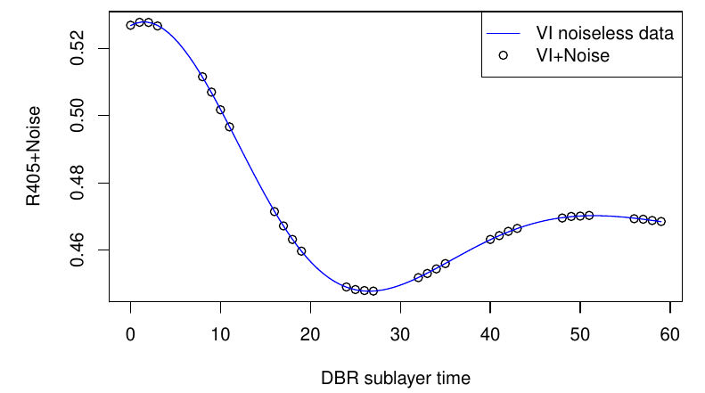

Fig. 1a) Idea of Merge Line analysis (Laytec). Fig 1b) Example of generated reflectance profile for 4 wafers.

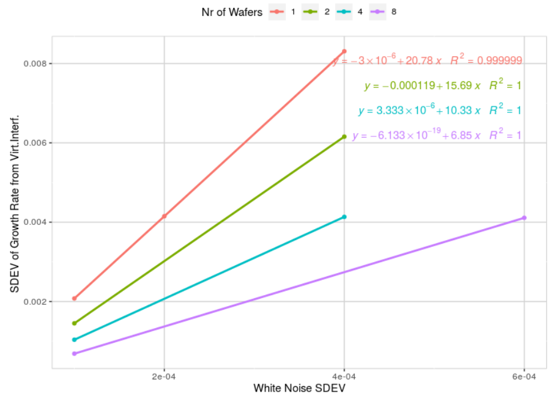

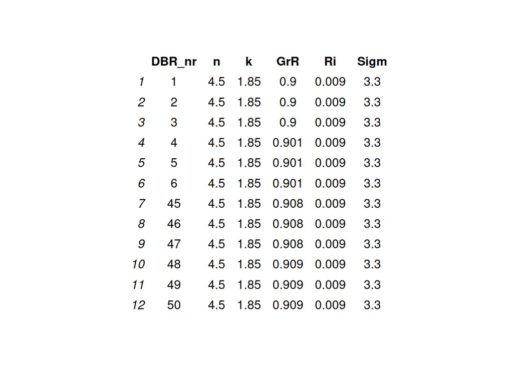

Fig. 2 SDEV of noise vs SDEV of Growth Rate.

The uncertainty of gr rate extraction affect Feed Forward recipe correction, as illustrated on Fig. 3. If we would extract GrR from single wafer, without Merge Line, then 10 and 20 periods are not enough to reveal true growth rate drift (Fig. 3 left).

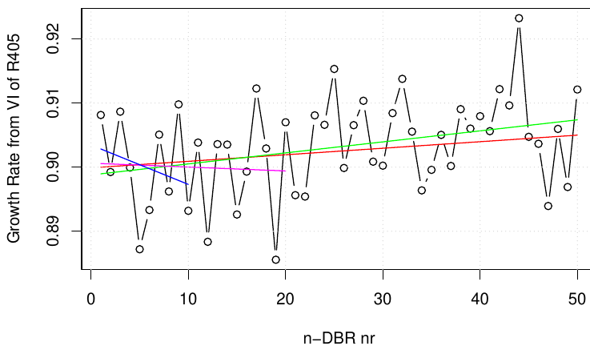

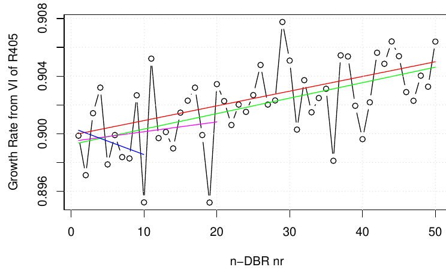

Fig. 3 Growth Rate extraction from simulation with 4e-4 white noise. Left 1 wafer case, right 8wfr Merge Line case, there is true growth rate drift from 0.9 to 0.909 nm/s, over 50 repeats.

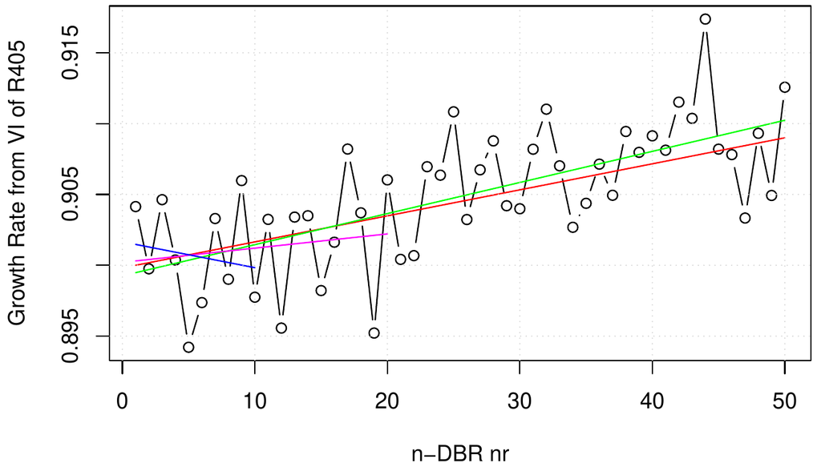

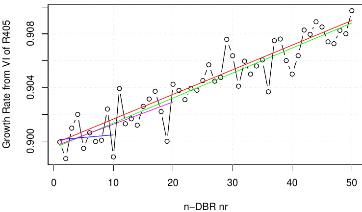

Fig. 4 Simulation with 2e-4 white noise. Left 1 wafer case, right 8wfr Merge Line case, there is true growth rate drift from 0.9 to 0.909 nm/s, over 50 repeats.

If noise is 2e-4 (Fig. 4), then 20 repeats is enough to see true drift pattern without Merge Line, and 8x Merge Line get very close to true drift in 20 repeats.

# 3 Noise in Real runs

In real runs noise do not have same mean and distribution on wafers. This sections shows data extracted from LayTec Epi-Curve software.

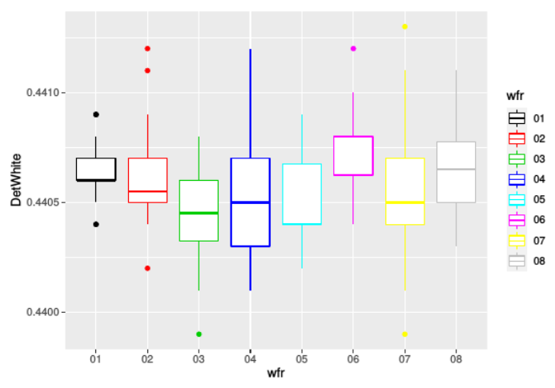

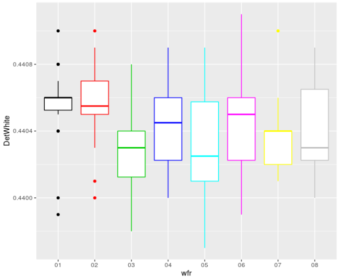

Growth rates for wafers 3,4,5 are much higher than rest (fig. 6), though boxplot of fitting residuals do not show big variations.

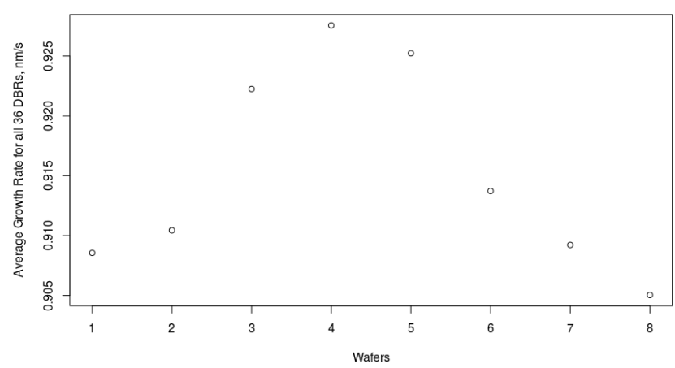

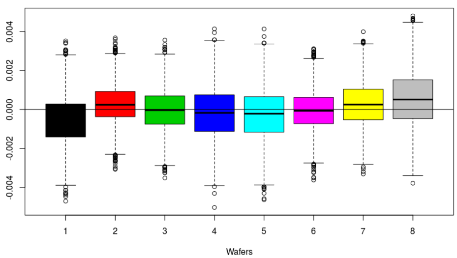

Fig.6 Average growth rates extracted(left), and boxplot of residuals from fitting(right), which might be treated as measure of noise during growth.

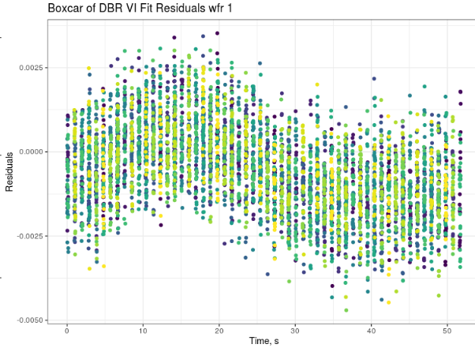

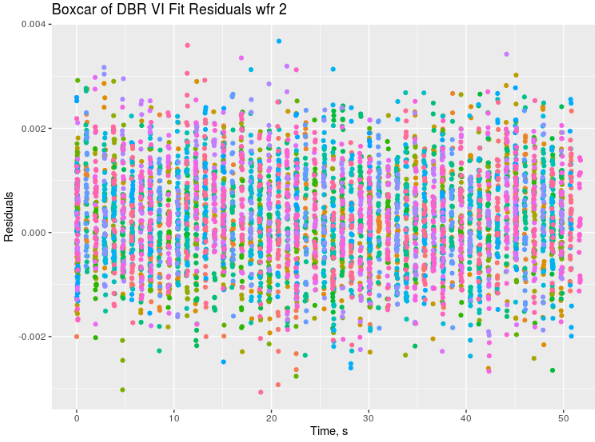

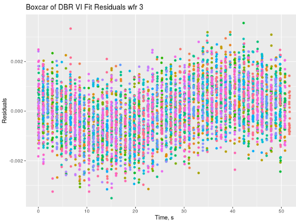

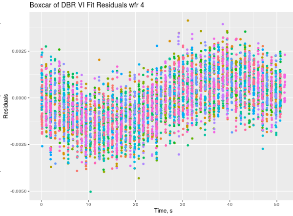

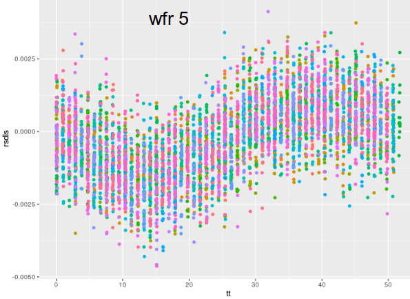

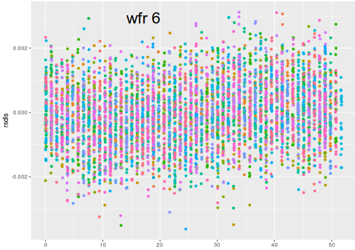

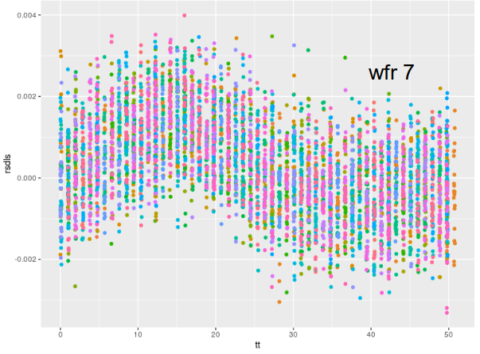

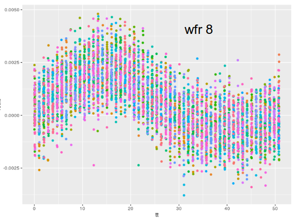

Fig. 7 Plots of residuals from fitting from each wafer, shows that residuals distribution is different on wfr 3, 4, and 5. Merge line should be applied to 3 groups separately: 3+4+5, 2+6 and 1+7+8 which are similar.

# 4 Machine Learning for F-P Dip Prediction

The growth rate fitting algorithm, was used to build Machine Learning model, which would be able to predict F-P dip in VCSEL. The data sample were 3 runs with 8 wafers each. The test case data sample were 2 runs with 8 wafers, which model (trained only on 3 runs) never seen before.

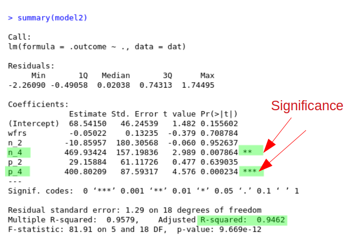

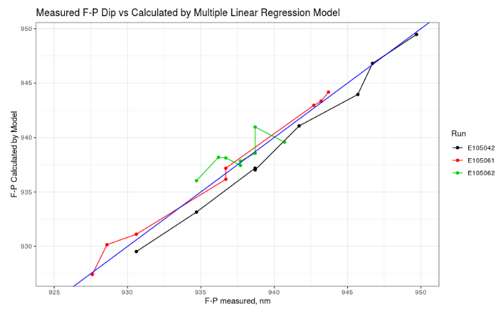

The model found, that only wafers with high Al content are responsible for F-P dip variation.

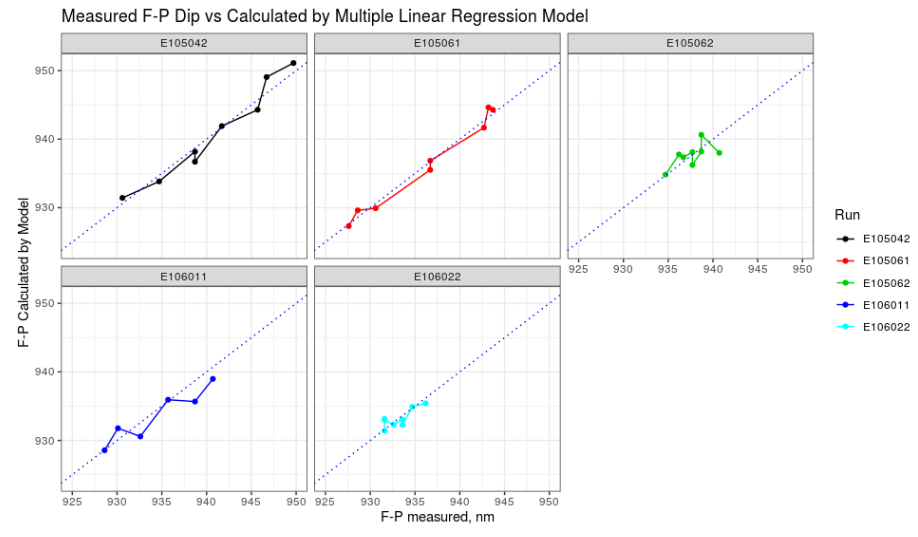

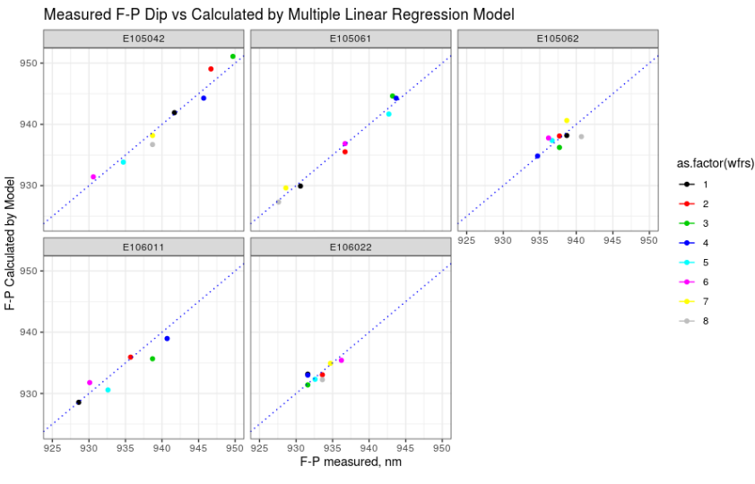

The model achieved 1.26nm and 1.29nm error on train data, Root Mean Squared Error and SDEV respectively.  
On full 5x8 wafers data set, the RMSE and SDEV were 1.4nm, and 1.42nm. The model could be improved by adding pyrometry and curvature data.

# 5 Conclusions

1. Set of scripts were developed for assistance in analysis *in-situ* data of VCSELs growth
2. Monitoring thin layers in Multi-wafer reactors are challenging, perhaps best strategy is to mix pre-growth[2] calibrations with in-situ monitoring.
3. Machine Learning algorithms could assist in automating analysis and improving yield.

# References

[1]

W. G. Breiland and K. P. Killeen, “A virtual interface method for extracting growth rates and high temperature optical constants from thin semiconductor films using *in* *Situ* normal incidence reflectance,” *Journal of Applied Physics*, vol. 78, no. 11, pp. 6726–6736, Dec. 1995, doi: 10.1063/1.360496. [Online]. Available: http://aip.scitation.org/doi/10.1063/1.360496. [Accessed: 07-Jul-2022]

[2]

W. G. Breiland, H. Q. Hou, H. C. Chui, and B. E. Hammons, “In situ pre-growth calibration using reflectance as a control strategy for MOCVD fabrication of device structures,” *Journal of Crystal Growth*, vol. 174, no. 1–4, pp. 564–571, Apr. 1997, doi: 10.1016/S0022-0248(97)00020-1. [Online]. Available: https://linkinghub.elsevier.com/retrieve/pii/S0022024897000201. [Accessed: 07-Jul-2022]